# QTM 151 - Quiz 1

## Try to submit as an HTML file

Print your name below

```python
# Write your answer here
print("Matthew Dang")
```

```
Matthew Dang
```

This quiz is open book

- You can use the lecture notes
- You will get partial credit for attempting the questions
- To get full credit, the code should work as intended
- You should NOT communicate with other students

Print the following message:

"I will abide by Emory's code of conduct"

```python
# Write your answer here:
print("I will abide by Emory's code of conduct")
```

```
I will abide by Emory's code of conduct
```

Import the libraries "numpy", "matplotlib.pytplot", and "pandas"

```python
# Write your answer here
import numpy as np
import matplotlib.pyplot as plt
import pandas as pd
```

(a) IF/ELSE statements

- Create two lists:

`list_p = ["Introduction","to","Python"]`  
`list_r = ["Intro","to","R"]`

- Create a new variable `keyword = "Introduction"`
- Create an if/else that tests whether `keyword` is part of either

list. Print your a message (you choose which message) if the test is true.

HINT: Use the "in" command to test whether an element is part  
of a list (see Lecture 4)

```python
# Write your answer here:
list_p = ["Introduction", "to", "Python"]
list_r = ["Intro", "to", "R"]
keyword = "Introduction"
if keyword in list_p or list_r:
    print("True")
else:
    print("False")
```

```
True
```

(a) Transform a list of values and plot it

- Create an array with the following values

`coord_x = [1,4, 0, -1, 20, 40]`

`coord_y = [2,2, 0, 10, 0, 1]`

- Create a new vector `hypotenuse` with the following formula

$\qquad hypotenuse = x^2 + y^2$

- Produce a histogram of the variable hypotenuse
- Label the axes and the title
- Change the color to "orange", "green" or "purple" (you choose)

Hint: You can use numpy functions

```
[   5   20    0  101  400 1601]
```

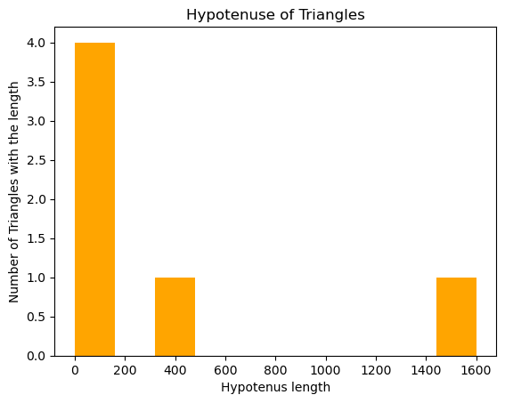

```python
# Write your answer here:
coord_x = np.array([1, 4, 0, -1, 20, 40])
coord_y = np.array([2, 2, 0, 10, 0, -1])
hypotenuse = (coord_x ** 2)+(coord_y ** 2)
print(hypotenuse)
plt.hist(hypotenuse, color = "Orange")
plt.title("Hypotenuse of Triangles")
plt.xlabel("Hypotenus length")
plt.ylabel("Number of Triangles with the length")
```

(c) Plot random variables ...

- Let $n = 500$
- Generate "vec_x" from a normal (loc = 0,scale = 1,size = n)
- Generate "vex_z" from a normal (loc = 5,scale = 1,size = n)
- Plot two histograms
  - Label the axes and title
  - Each graph should have a different title

To get full points, plot the scatter plots on a single row using the  
subplots syntax (see Lecture 6)

[output not shown]

[output not shown]

[figure not shown]

```python
# Write your answer here:
n = 500

vec_x = np.random.normal(loc = 0, scale = 1, size = n)
vex_z = np.random.normal(loc = 5, scale = 1, size = n)
fig, list_subfig = plt.subplots(1,figsize = [12,3])
plt.tight_layout(pad = 10, h_pad = 5)
list_subfig[n].scatter(vec_x)
list_subfig[n].set_title("Distribution of X when n is ")
list_subfig[n].set_ylabel("Frequency")
list_subfig[n].set_xlabel("Values of X")
```

(d) Combine information across datasets

- Read the dataset "/data_quiz/germany_co2_emissions.csv" and store it as "data_germany"
- View the dataset, and see what variables it contains
- Plot a figure on CO2 emissions with the following characteristics
  - The yearly variable on the x-axis.
  - Plots of Germany's CO2 emissions on the y-axis.
  - Label the axes

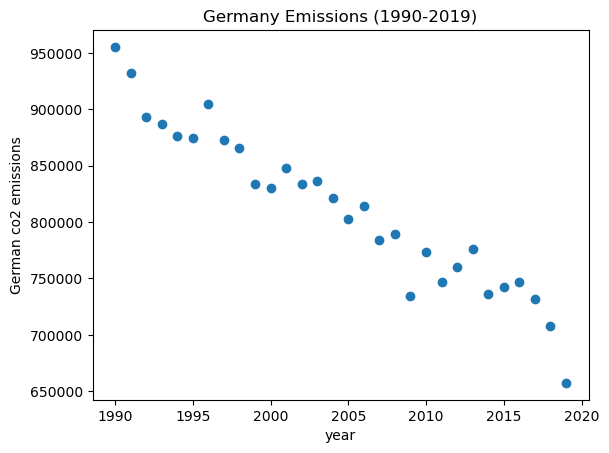

```python
# Write your answer here:
file_path = r"C:\Users\Matthew Dang\qtm151\Quiz1\data_quiz\germany_co2_emissions.csv"
data_germany = pd.read_csv(file_path)
germany_list = ["year", "total_emissions"]
plt.scatter(x = data_germany["year"], y = data_germany["total_emissions"])
plt.xlabel("year")
plt.ylabel("German co2 emissions")
plt.title("Germany Emissions (1990-2019)")
plt.show()
```

(e) Loop through dfferent variables and plot

- Read the dataset "data_quiz/wdi_ageprop_2020.csv"
- Create a list of variable names with the following elements:

`list_varnames = ["percent_ages0to14","percent_ages15to64"]`

- Run a for loop that computes the mean for each variable and print it on screen.

```python
# Write your answer here:
loop_dataset = pd.read_csv(r"C:\Users\Matthew Dang\qtm151\Quiz1\data_quiz\wdi_ageprop_2020.csv")
list_varnames = np.array(["percent_ages0to14", "percent_ages15to64"])
means_np = {var: np.mean(loop_dataset[var]) for var in list_varnames}
means_np
```

```
{'percent_ages0to14': 26.90657125728302,
 'percent_ages15to64': 63.68465159973585}
```

(f) Run loop through different datasets and compute statistics

- Create a list with the ".csv" dataset names of two countries. For example,

`["data_quiz/name1.csv","data_quiz/name2.csv"]`

- Create an empty list called `list_emissions`
- Run a for-loop over the list of dataset names. Inside the loop:
  - Read the corresponding ".csv" dataset.
  - Compute the mean of "total_emissions" for each respective country,

  and store it as an element of `list_emissions`
- Print `list_emissions`

HINT: Use `.append()` (See Lecture 5)

```python
# Write your answer here:
dataset_files = ["C:\Users\Matthew Dang\qtm151\Quiz1\data_quiz\china_co2_emissions.csv", "C:\Users\Matthew Dang\qtm151\Quiz1\data_quiz\india_co2_emissions.csv"]
list_emissions = []
for file in dataset_files:
    df = pd.read_csv(dataset_files)
```

[output not shown]